# Further RNA-seq Analysis

Mark Dunning (Acknowledgements: Oscar Rueda, Matt Ritchie, Christina Curtis)

Last modified: 23 Mar 2016

# Clustering (and PCA)

# Clustering.. or Classification?

- **Unsupervised:** classes unknown, want to discover them from the data (cluster analysis)
- **Supervised:** classes are predefined, want to use a (training or learning) set of labelled objects to form a classifier for classification of future observations

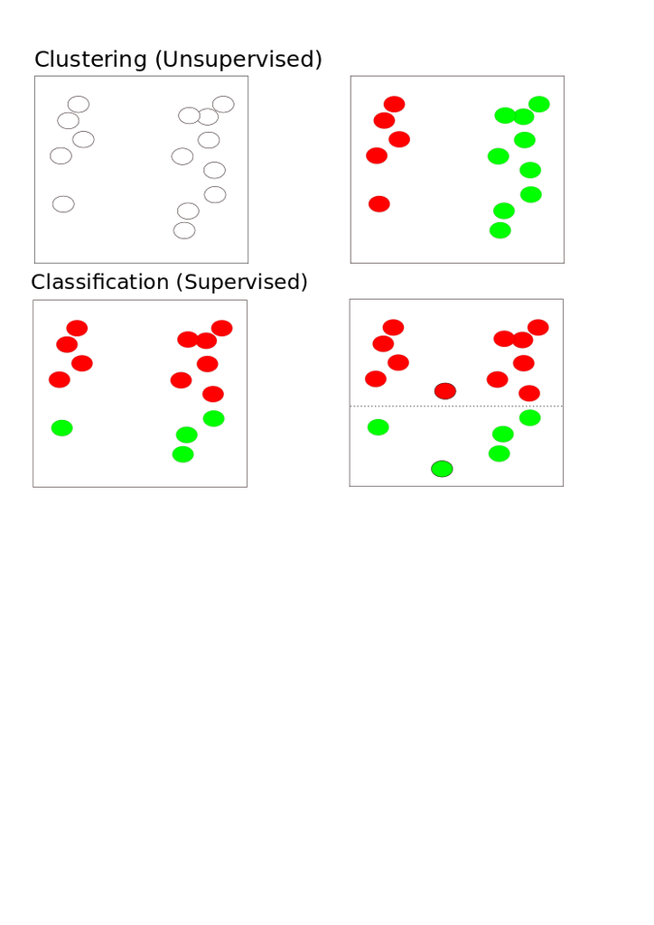

# Why do clustering for genomic data?

- Clustering leads to readily interpretable figures and can be helpful for identifying patterns in time or space.
- We can cluster samples (columns)
  - e.g. identification of new / unknown tumor classes using gene expression profiles
- We can cluster genes (rows)
  - e.g. using large numbers of yeast experiments to identify groups of co-regulated genes
  - we can cluster genes to reduce redundancy (i.e. variable selection) in predictive models

# Subtype Discovery

- There are plenty of examples of using clustering to discover subtypes in the literature

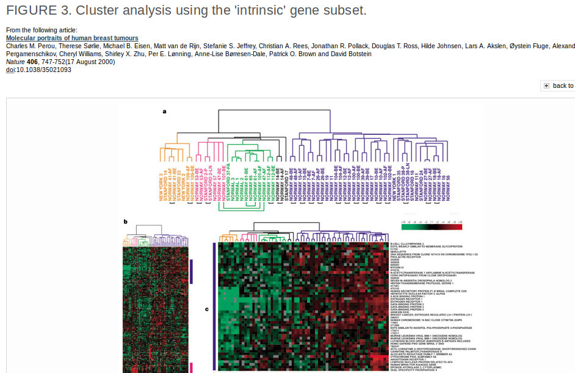

# Clustering as QA

- Also used as a quality assessment tool
  - to check for outlier samples
  - (microarray data)

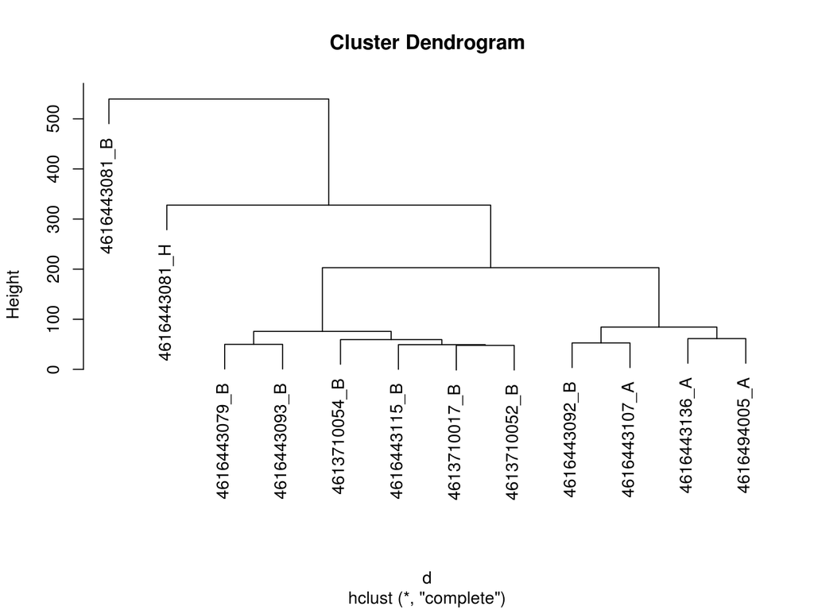

# Clustering as QA

- Can check within / between experiment variability and potential confounding factors (batch effect etc)

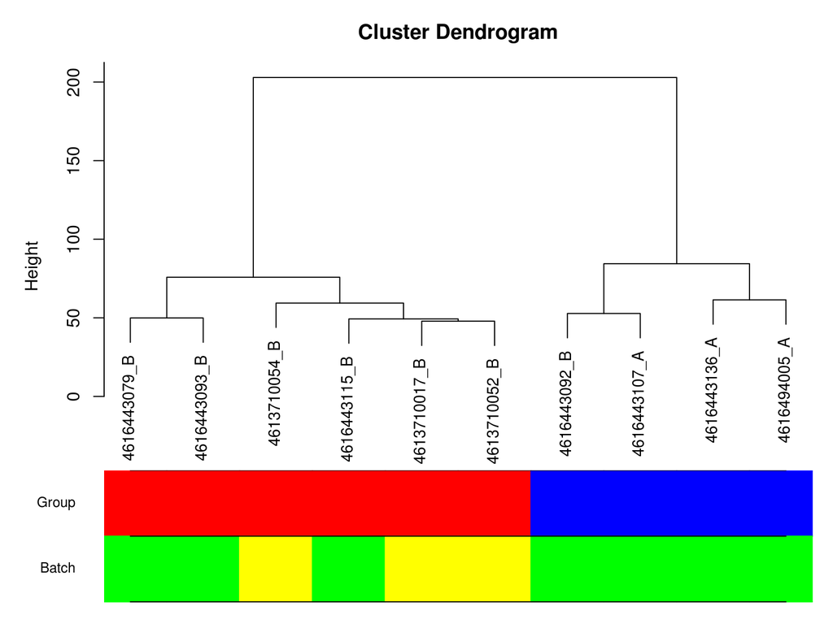

# Clustering Overview

- Steps in a Cluster Analysis
  1. Preprocess the data
  2. Choose a *dissimilarity* measure
  3. Choose a cluster algorithm
  4. Select the number of clusters
  5. Validate the procedure

# Preprocessing

When clustering genes, it is common to pre-process;

- normalise
- filter; remove genes with low variability across samples and many missing values
- (impute missing values)
- standardise; e.g. zero-mean and, unit variance:
  - $y_g^* = (y_g - \mu_g)/\sigma_g$

# How to compute similarity

Common *Similarity* / *Dissimilarity* measures include

- Correlation coefficient; *scale invariant*
  - Pearson’s correlation;
  - Spearman correlation of ranks
- Distance: scale dependant
  - Euclidean distance; $d(x,y) = \sqrt{\sum_i (x_i - y_i)^2}$
  - City block (Manhattan) distance; $d(x,y) = \sum | x_i - y_i |$
  - and others…..
- *Warning*: Don’t get too hung-up on the choice of measure
  - Clustering is primarily an exploratory tool
  - If your data has signal, it should show regardless of which measure you choose
  - Don’t just pick the one which “looks the best”

# How to compute similarity, in R

The `dist` function can be used to calculate a variety of similarity measures

- As usual, we can do `?dist`.
- The input is a matrix of numerical values
- Let’s test with some sample data

```r
myMatrix <- matrix(rnorm(1000),ncol=10)
colnames(myMatrix) <- LETTERS[1:10]
head(myMatrix)
```

```
##               A          B          C          D          E          F
## [1,]  0.4313777 -2.4670200 -0.7073725  0.3194366  0.8602843 -0.7072524
## [2,] -0.1119854  0.2155933  1.3840235 -2.1342261  0.4873031 -1.4214807
## [3,] -0.8989685  0.4339697  1.5643489 -0.1795468  0.1206374  0.8601242
## [4,]  0.6369946 -0.9573872  0.1323738 -0.3081852  1.0382901 -0.8216086
## [5,]  0.1357330  0.2440095  1.1538843 -1.0067510 -1.3158878 -0.2761261
## [6,]  0.6717109 -1.4595497 -0.2515446 -1.5297978  1.1495169  1.6037638
##               G          H          I          J
## [1,] -0.6794123 -1.6310056  0.4481794 -1.2323060
## [2,]  0.8233594  1.1139286 -0.8939646  1.2021941
## [3,]  0.3049781 -0.1753819  1.5622296 -0.5362093
## [4,] -1.9204444 -1.5448343  0.4831130 -0.9426206
## [5,] -0.5078418 -2.5823836  0.4086202 -2.2609447
## [6,] -0.6668203  1.2564544  2.1929750 -0.7531744
```

# How to compute similarity, in R

- The default is to compute distances from the *rows* of the matrix
  - i.e. which would normally be the genes we are measuring
- Also note that the matrix has some values that appear to be missing
  - why do you think that might be?

```r
d <- dist(myMatrix)
d
```

[output not shown]

# How to compute similarity, in R

- The more common use of clustering is to cluster the columns (*samples*)
- To do this, we have to *transpose* the matrix; using the function `t`

```r
d <- dist(t(myMatrix))
d
```

```
##          A        B        C        D        E        F        G        H
## B 14.08415
## C 14.88023 15.01007
## D 15.07597 13.81700 13.92782
## E 15.30797 15.18065 12.91680 14.36210
## F 13.92214 15.01753 14.35741 12.90844 14.22044
## G 16.78331 15.87847 14.93457 14.26315 13.65642 14.24959
## H 15.18897 14.91864 13.59910 13.75474 13.14450 13.81787 14.26011
## I 15.21106 15.15853 13.90017 13.34724 14.63817 12.75963 16.45115 13.91325
## J 16.24253 14.95350 14.28564 14.37443 14.50068 15.69133 14.79427 14.30121
##          I
## B
## C
## D
## E
## F
## G
## H
## I
## J 15.45298
```

# How to compute similarity, in R

- Changing the type of distance measure can be done by changing the `method` argument

```r
d.man <- dist(t(myMatrix),method="manhattan")
d.man
```

```
##          A        B        C        D        E        F        G        H
## B 115.2690
## C 122.7021 121.9089
## D 122.9448 113.7223 109.2488
## E 121.8248 116.7150 104.0412 117.9643
## F 111.4721 121.4489 118.7915 105.4497 116.4869
## G 133.4619 132.4103 120.1602 110.9659 108.6304 109.9150
## H 122.5602 114.8863 110.4001 106.7878 105.2342 114.3228 114.1843
## I 122.4814 121.2553 114.1197 101.7003 117.7069 101.9944 131.5409 111.6427
## J 131.3290 123.4407 115.3894 114.4036 122.6288 122.0493 122.2218 117.2269
##          I
## B
## C
## D
## E
## F
## G
## H
## I
## J 125.1519
```

# How to calculate correlation in R

- This time we use the `cor` function (`?cor`)
- What do you notice about the output, compared to that of `dist`?

```r
cor(myMatrix)
```

```
##             A             B            C           D           E
## A  1.00000000  0.1873257371 -0.023000453 -0.08803428 -0.13080526
## B  0.18732574  1.0000000000 -0.011511807  0.10968627 -0.08226229
## C -0.02300045 -0.0115118072  1.000000000 -0.03532202  0.10502192
## D -0.08803428  0.1096862726 -0.035322018  1.00000000 -0.16237803
## E -0.13080526 -0.0822622909  0.105021917 -0.16237803  1.00000000
## F  0.10557545  0.0004291339 -0.040904036  0.13286359 -0.06779513
## G -0.18307097 -0.0408289615 -0.033375088  0.01087487  0.09412331
## H -0.12118891 -0.0463548665  0.004657798 -0.06479482  0.02138155
## I -0.01338224  0.0169886817  0.066632105  0.10070537 -0.08673286
## J -0.14899699  0.0576154555  0.028275765 -0.02098191 -0.04670010
##               F           G            H           I           J
## A  0.1055754466 -0.18307097 -0.121188905 -0.01338224 -0.14899699
## B  0.0004291339 -0.04082896 -0.046354867  0.01698868  0.05761546
## C -0.0409040361 -0.03337509  0.004657798  0.06663211  0.02827576
## D  0.1328635922  0.01087487 -0.064794815  0.10070537 -0.02098191
## E -0.0677951324  0.09412331  0.021381549 -0.08673286 -0.04670010
## F  1.0000000000  0.08674360 -0.018787424  0.22943055 -0.16930951
## G  0.0867435951  1.00000000  0.015941398 -0.19833124  0.05636269
## H -0.0187874244  0.01594140  1.000000000  0.01838101 -0.02447738
## I  0.2294305467 -0.19833124  0.018381014  1.00000000 -0.07764364
## J -0.1693095113  0.05636269 -0.024477377 -0.07764364  1.00000000
```

# How to calculate correlation in R

- Clustering algorithms will expect input in distance matrix form
- We can convert using `as.dist`

```r
corMat <- as.dist(cor(myMatrix))
corMat
```

```
##               A             B             C             D             E
## B  0.1873257371
## C -0.0230004526 -0.0115118072
## D -0.0880342757  0.1096862726 -0.0353220181
## E -0.1308052649 -0.0822622909  0.1050219171 -0.1623780286
## F  0.1055754466  0.0004291339 -0.0409040361  0.1328635922 -0.0677951324
## G -0.1830709748 -0.0408289615 -0.0333750883  0.0108748704  0.0941233070
## H -0.1211889054 -0.0463548665  0.0046577978 -0.0647948150  0.0213815490
## I -0.0133822445  0.0169886817  0.0666321053  0.1007053715 -0.0867328634
## J -0.1489969940  0.0576154555  0.0282757647 -0.0209819071 -0.0467000977
##               F             G             H             I
## B
## C
## D
## E
## F
## G  0.0867435951
## H -0.0187874244  0.0159413977
## I  0.2294305467 -0.1983312437  0.0183810136
## J -0.1693095113  0.0563626950 -0.0244773771 -0.0776436408
```

# How to calculate correlation in R

- Two samples with a *higher correlation* values means *more similar*
- …so the *distance* between is *less*

```r
corMat <- as.dist(1-abs(cor(myMatrix)))
corMat
```

```
##           A         B         C         D         E         F         G
## B 0.8126743
## C 0.9769995 0.9884882
## D 0.9119657 0.8903137 0.9646780
## E 0.8691947 0.9177377 0.8949781 0.8376220
## F 0.8944246 0.9995709 0.9590960 0.8671364 0.9322049
## G 0.8169290 0.9591710 0.9666249 0.9891251 0.9058767 0.9132564
## H 0.8788111 0.9536451 0.9953422 0.9352052 0.9786185 0.9812126 0.9840586
## I 0.9866178 0.9830113 0.9333679 0.8992946 0.9132671 0.7705695 0.8016688
## J 0.8510030 0.9423845 0.9717242 0.9790181 0.9532999 0.8306905 0.9436373
##           H         I
## B
## C
## D
## E
## F
## G
## H
## I 0.9816190
## J 0.9755226 0.9223564
```

# Correlation versus Distance

- A simple toy example of three genes
  - which genes seem to be closest?

[figure not shown]

# Correlation versus Distance

- Using Euclidean distance

```
##           gene1     gene2
## gene2 6.3245553
## gene3 0.6057322 6.0805548
```

- Correlation matrix

```
##           gene1     gene2     gene3
## gene1 1.0000000 1.0000000 0.9797137
## gene2 1.0000000 1.0000000 0.9797137
## gene3 0.9797137 0.9797137 1.0000000
```

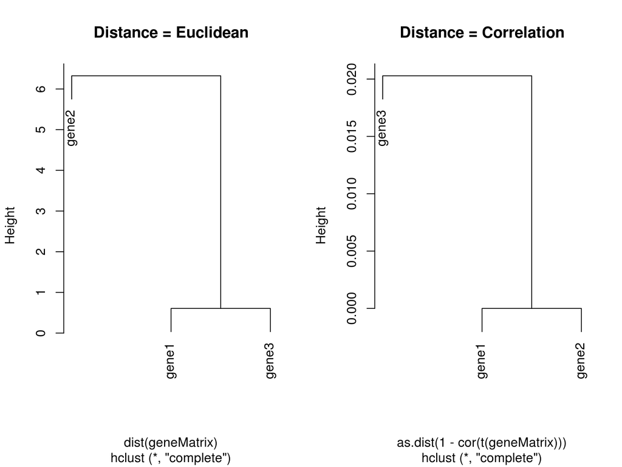

# Choice of algorithm

Clustering Algorithms

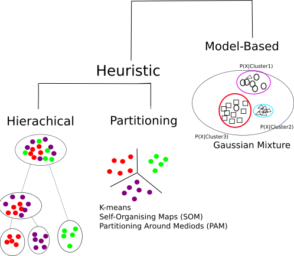

# Hierachical methods

- start with *n* samples (or $p$ gene) clusters
- At each step, *merge* the two closest clusters using a measure of *between-cluster* dissimilarity which reflects the shape of the clusters
- The distance between the clusters is defined by the method used (e.g. in *complete linkage*, the distance is defined as the distance between the furthest pair of points in the two clusters)

# Hierachical methods

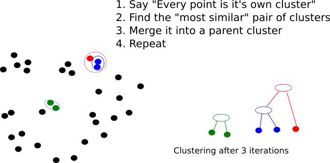

# Between-cluster dissimilarity measures

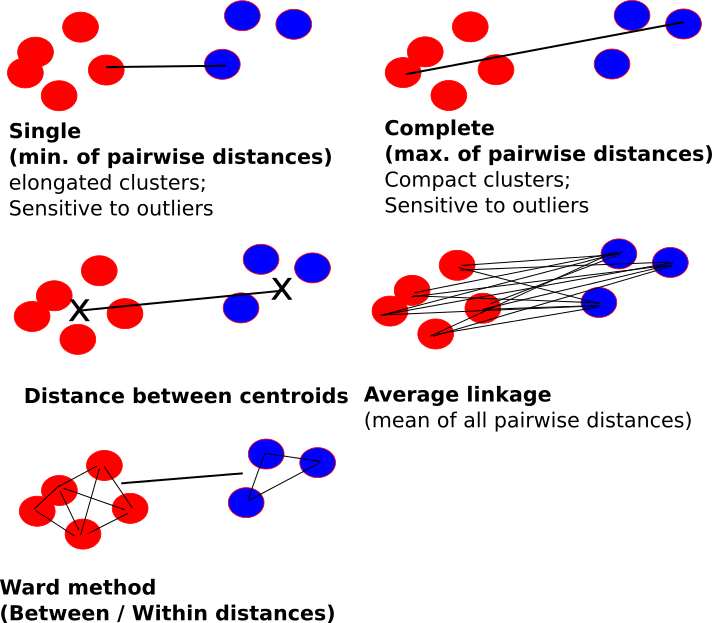

# Hierachical Clustering

- Dendrograms are good visual guides, but *arbitrary*
- Nodes can be reordered
  - Closer on dendrogram $\ne$ more similar

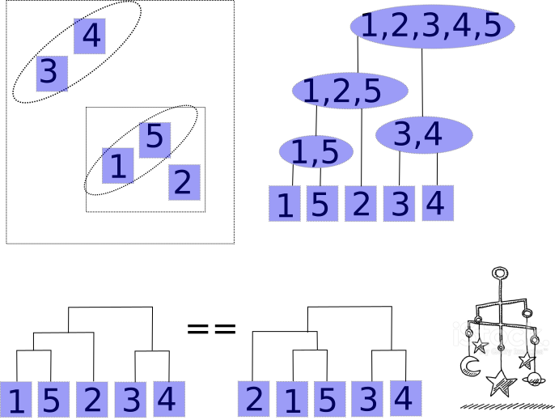

# Performing hierachical clustering, in R

- The function to use here is `hclust` (`?hclust`)
- It takes a distance matrix that you computed previously

```r
clust <- hclust(d)
clust
```

```
##
## Call:
## hclust(d = d)
##
## Cluster method   : complete
## Distance         : euclidean
## Number of objects: 10
```

# Performing hierachical clustering, in R

- The standard plotting function has been extended to visualise the result of the clustering

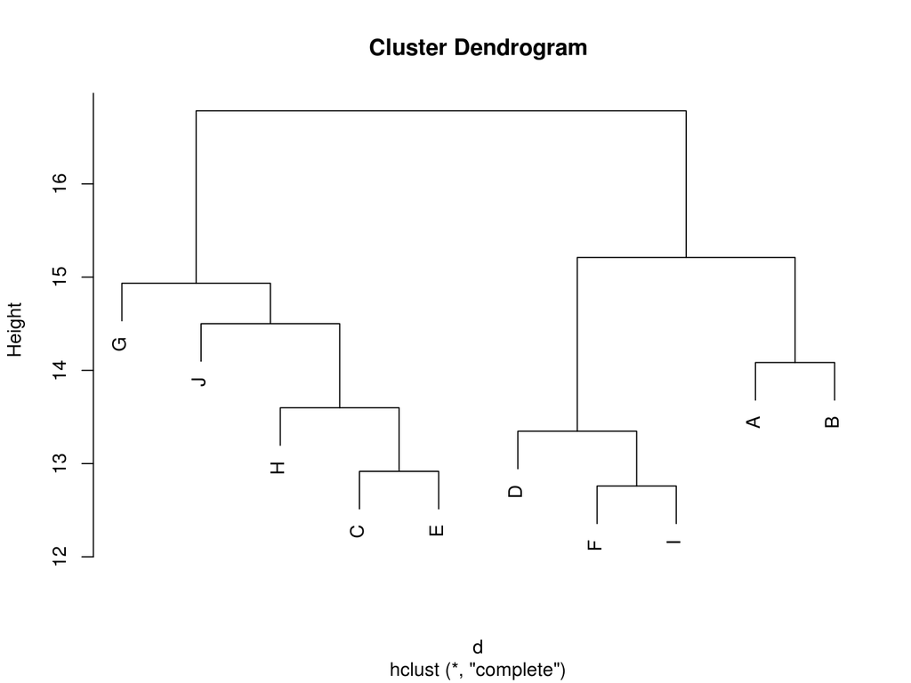

```r
plot(clust)
```

# Performing hierachical clustering, in R

- We can change the name of the method

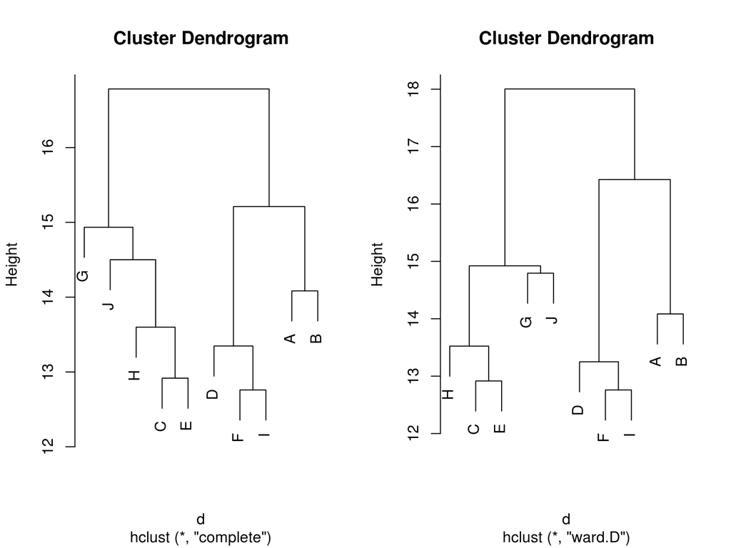

```r
clust.ward <- hclust(d,method = "ward.D")
par(mfrow=c(1,2))
plot(clust)
plot(clust.ward)
```

# Accessing the clustering object

- Two useful functions are `cutree` and `rect.hclust`
- Can be used to “cut” the dendrogram at a particular height

```r
par(mfrow=c(1,1))
plot(clust)
cutree(clust, h=16)
```

```
## A B C D E F G H I J
## 1 1 2 1 2 1 2 2 1 2
```

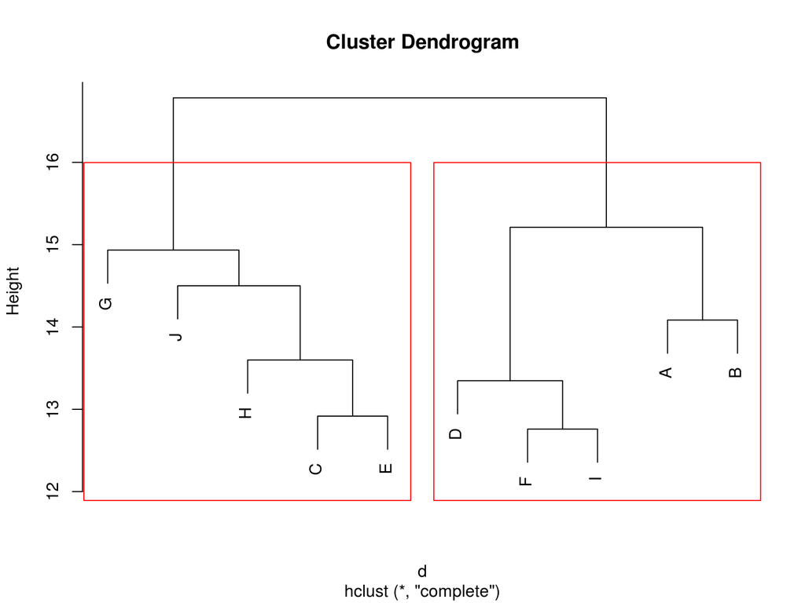

```r
rect.hclust(clust, h=16)
```

# Accessing the clustering object

- Alternatively, we can see the number of clusters; *k*
- Try experimenting with different values of k….

```r
plot(clust)
cutree(clust, k=2)
```

```
## A B C D E F G H I J
## 1 1 2 1 2 1 2 2 1 2
```

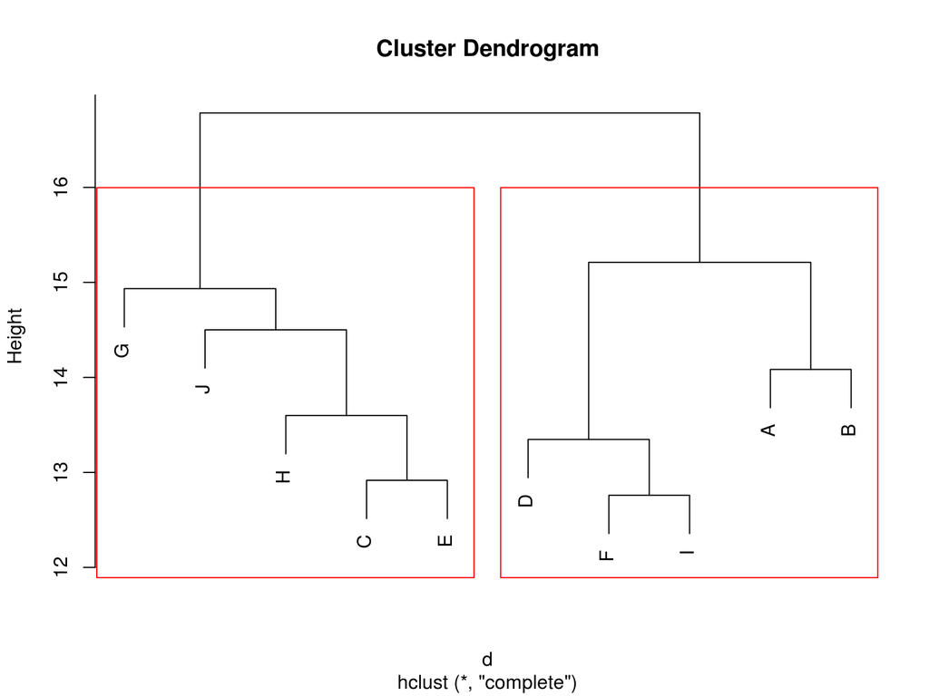

```r
rect.hclust(clust, k=2)
```

# What is the optimal number of clusters?

- A measure called the *silhouette width* can be computed.
- The silhouette measures how well-matched an object is to others in it’s own cluster, versus how well-matched it would be if it were moved to the next closest cluster
- Value around 0 -> a gene lies between two clusters
- Value of -1 -> gene is similar to element in neighbour cluster and probably in the wrong cluster
- Value of around 1 -> good clustering
- Output from `silhouette` function for the gene expression example earlier

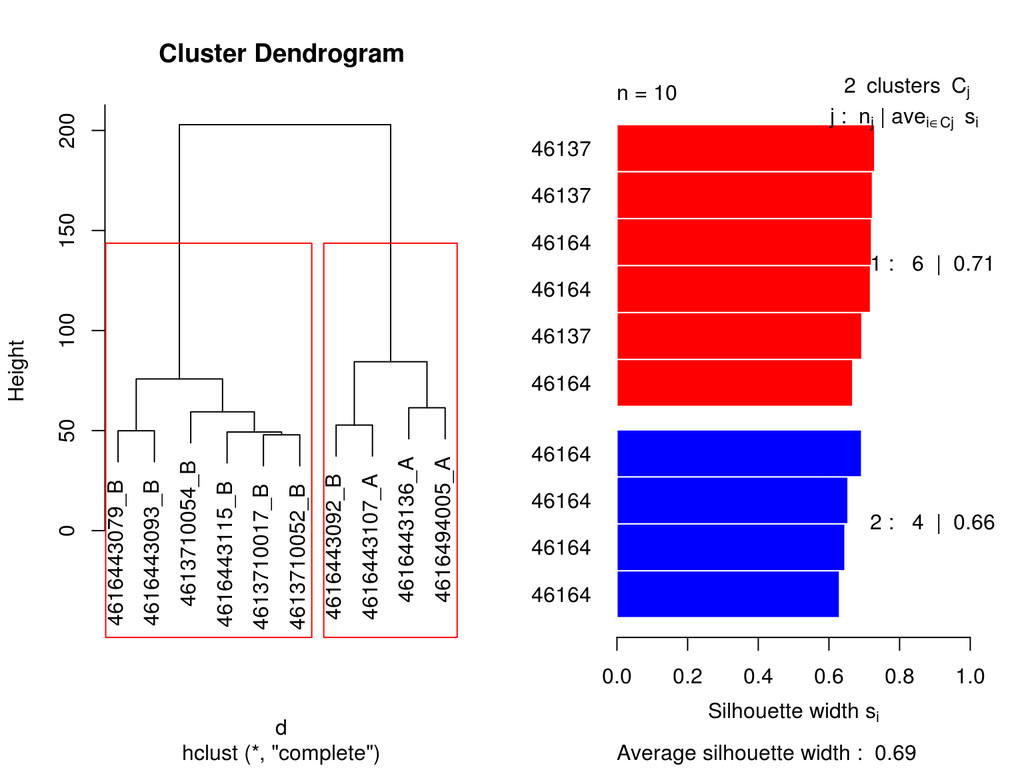

# Summary of clustering

- Useful as *exploratory / visualisation* tools
- Choice of metric, methods and parameters usually guided by prior knowledge about the question
  - The result is guided by what you are looking for
- Validate using different algorithms
- Use prior Biological knowledge, or your sample meta data to see if the clusters make sense
- Be aware
  - Clustering will always produce something. It cannot NOT work

# Application of clustering to RNA-seq

- Clustering is a generic technique that can be applied to many forms of data
  - We will use it on RNA-seq, but it can be used on ChIP-seq (see tomorrow), or DNA-seq data
- Quality assessment of samples
  - checking for batch effects and outliers
  - check effectiveness of normalisation / transformation

# Principal Components Analysis (PCA)

# Why Use PCA

- In genomic data, we have a large number of variables which are often highly correlated
- PCA is one of many *dimension-reduction* techniques that can remove redundancy and give a smaller more mangeable set of variables. In summary it can help us to:-
- Reduce *dimensionality* of the data
- Decrease the *redundancy* of the data
- Filter the *noise* in the data
- *Compress* the data

# PCA Example: Whisky

The data: 86 malt whiskies scored for 12 different taste categories

(https://www.mathstat.strath.ac.uk/outreach/nessie/nessie_whisky.html)

- Q. Can we find which whiskies have a similar taste profile?
- Q. What are the factors that determine the taste profile?

```
##           Body Sweetness Smoky Medicinal Tobacco Honey Spicy Winey Nutty
## Aberfeldy    2         2     2         0       0     2     1     2     2
## Aberlour     3         3     1         0       0     4     3     2     2
## AnCnoc       1         3     2         0       0     2     0     0     2
##           Malty Fruity Floral
## Aberfeldy     2      2      2
## Aberlour      3      3      2
## AnCnoc        2      3      2
```

# PCA Example

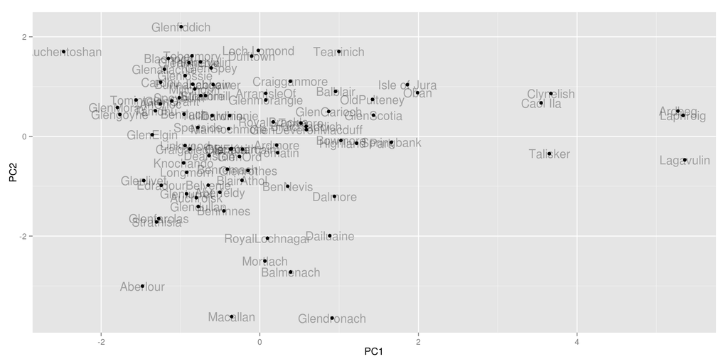

# PCA Example

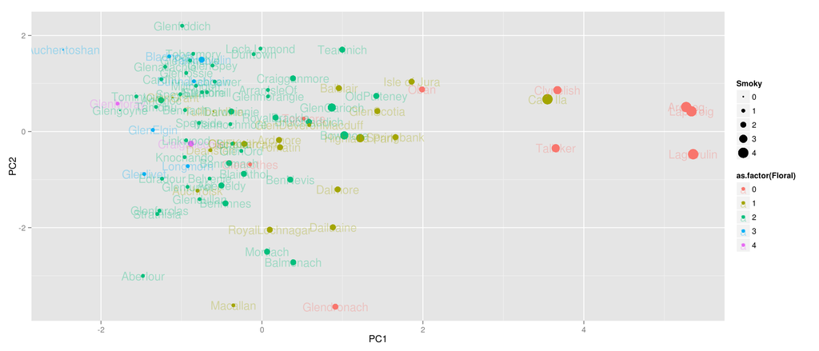

# More-relevant example

- MAQC microarrays with mixtures of Brain and Reference RNA (UHRR) at different concentrations
- Run in different labs
  - what do you notice?

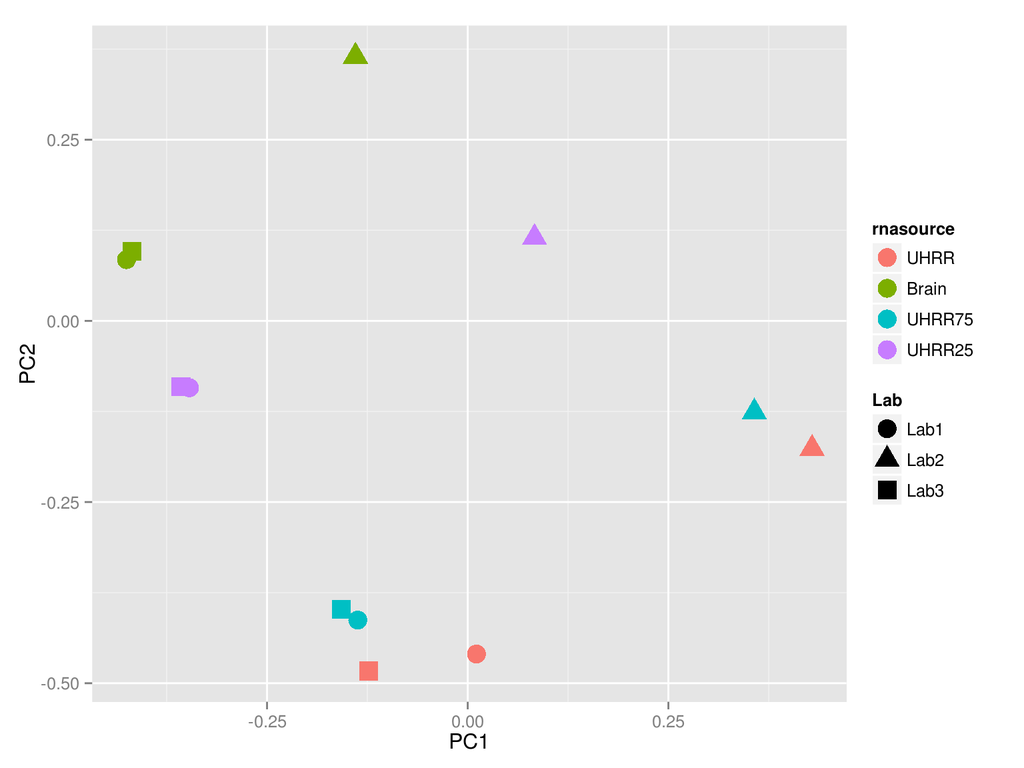

# More-relevant example

So, PCA can be used as a quality assessment tool and can inform us of any factors we need to account for in the analysis

- In this case we could correct for the batch effect, or add a batch factor to the linear model for analysis

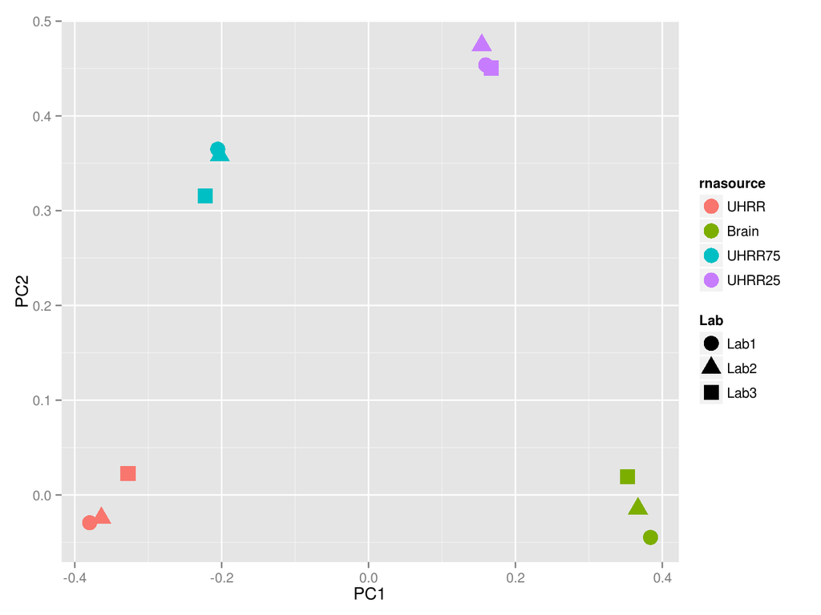

# What is going-on here?

A two-dimensional case

- Find direction of most variation (PC1)
- Direction that explains next amount of variation is orthogonal (at 90 degrees) (PC2)
- Each point on original x and y is a linear combination of PC1 and PC2
- Higher dimensional data can have many more components PC3, PC4….
  - although they will become increasingly less-influential

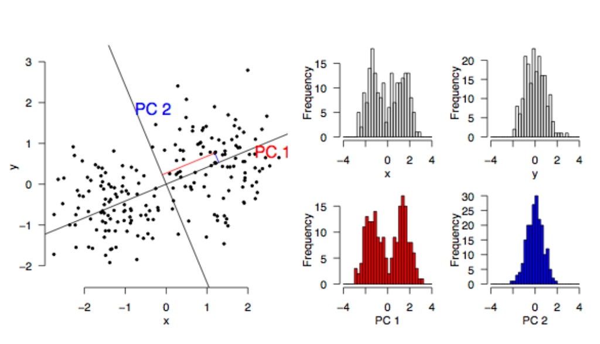

# Worked example

Getting the data…

```r
whisky <- read.csv("https://www.mathstat.strath.ac.uk/outreach/nessie/datasets/whiskies.txt")
scores <- whisky[,c(3:14)]
rownames(scores) <- whisky$Distillery
head(scores,n=3)
```

```
##           Body Sweetness Smoky Medicinal Tobacco Honey Spicy Winey Nutty
## Aberfeldy    2         2     2         0       0     2     1     2     2
## Aberlour     3         3     1         0       0     4     3     2     2
## AnCnoc       1         3     2         0       0     2     0     0     2
##           Malty Fruity Floral
## Aberfeldy     2      2      2
## Aberlour      3      3      2
## AnCnoc        2      3      2
```

# Running the PCA

The `prcomp` function does the hard-work for us

- It is computing *eigenvectors* and *eigenvalues* from our input matrix
  - or rather the covariance matrix
- We have 12 components (as we had 12 variables)
- The components are ordered according to the amount of variance they *explain*

```r
pca <- prcomp(scores)
summary(pca)
```

```
## Importance of components:
##                           PC1    PC2    PC3    PC4     PC5     PC6     PC7
## Standard deviation     1.5358 1.2270 0.8654 0.8039 0.75261 0.68513 0.63256
## Proportion of Variance 0.3011 0.1922 0.0956 0.0825 0.07231 0.05992 0.05108
## Cumulative Proportion  0.3011 0.4933 0.5889 0.6714 0.74370 0.80363 0.85471
##                            PC8     PC9    PC10    PC11    PC12
## Standard deviation     0.59943 0.52347 0.50049 0.42422 0.27266
## Proportion of Variance 0.04587 0.03498 0.03198 0.02297 0.00949
## Cumulative Proportion  0.90058 0.93556 0.96754 0.99051 1.00000
```

# Dissecting the PCA results

- Each column in a principal component
  - in decreasing order of importance
- The values are the measure of importance for each component
  - e.g. Smoky seems to be important for PC1
  - Smoky and Floral are opposite ends of the spectrum for PC1

```r
pca$rotation[,1:5]
```

```
##                   PC1         PC2           PC3         PC4          PC5
## Body       0.36119005 -0.49130643  0.0301178096 -0.07460952  0.227019231
## Sweetness -0.20298238 -0.04659634 -0.2638792230 -0.37063897  0.009220720
## Smoky      0.47794419 -0.06874216  0.2188100647  0.08852143 -0.201614612
## Medicinal  0.57527678  0.16079484  0.0431598432  0.08237288 -0.033120119
## Tobacco    0.09173306  0.02004776 -0.0006685359 -0.03337611 -0.008967789
## Honey     -0.22090804 -0.41799491  0.1102471134  0.03315990 -0.596888644
## Spicy      0.05811101 -0.17548310  0.6992443906 -0.17163088 -0.133792990
## Winey     -0.03745608 -0.63964979 -0.2331295871 -0.22573776  0.110928262
## Nutty     -0.04766410 -0.26036122 -0.1785529039  0.85059012  0.025288924
## Malty     -0.12781608 -0.10296202  0.1084169899  0.07177790 -0.105401421
## Fruity    -0.20235755 -0.12374977  0.4034627791  0.09457148  0.702770800
## Floral    -0.38394443  0.13074914  0.3433008365  0.14903423 -0.120141367
```

# How many components?

We look at the variance explained by each component and judge where it “drops-off”

- Sometimes called a “scree-plot”

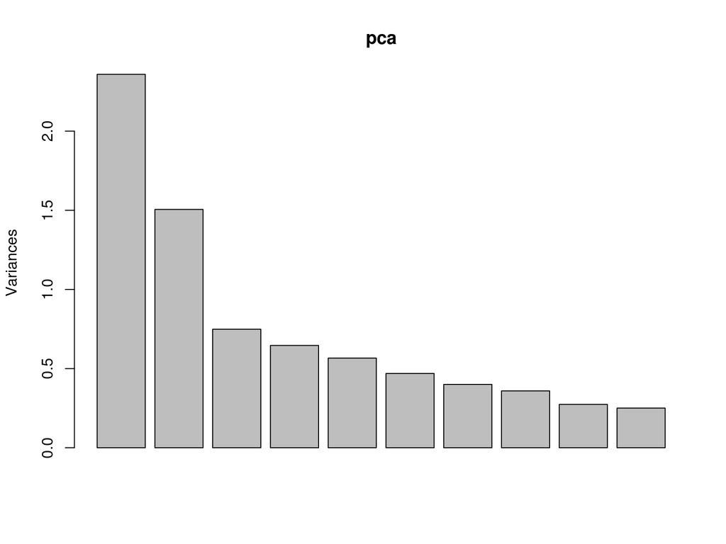

```r
plot(pca)
```

# How many components?

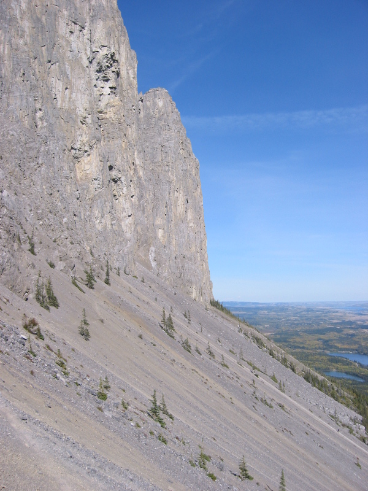

# Dissecting the PCA results

The new co-ordinate system is given by `pca$x`

- One row for each of our whiskies, one column for each component
- The original coordinates are a linear combination of the new ones
  - an exercise for the reader?

```r
pca$x[1:3,1:5]
```

```
##                  PC1        PC2        PC3        PC4        PC5
## Aberfeldy -0.5033841 -1.1220223 -0.1612002  0.5058255 -0.2841501
## Aberlour  -1.4788883 -3.0048507  1.5170911 -0.1385370 -0.7102894
## AnCnoc    -1.2531129  0.6537207 -0.2847196  0.9274739  0.1127587
```

# Dissecting the PCA results

`ggplot2` is especially convenient for visualising the results

- An overlay of the known variables will highlight the patterns
- As with clustering, PCA is to be used as an exploratory tool

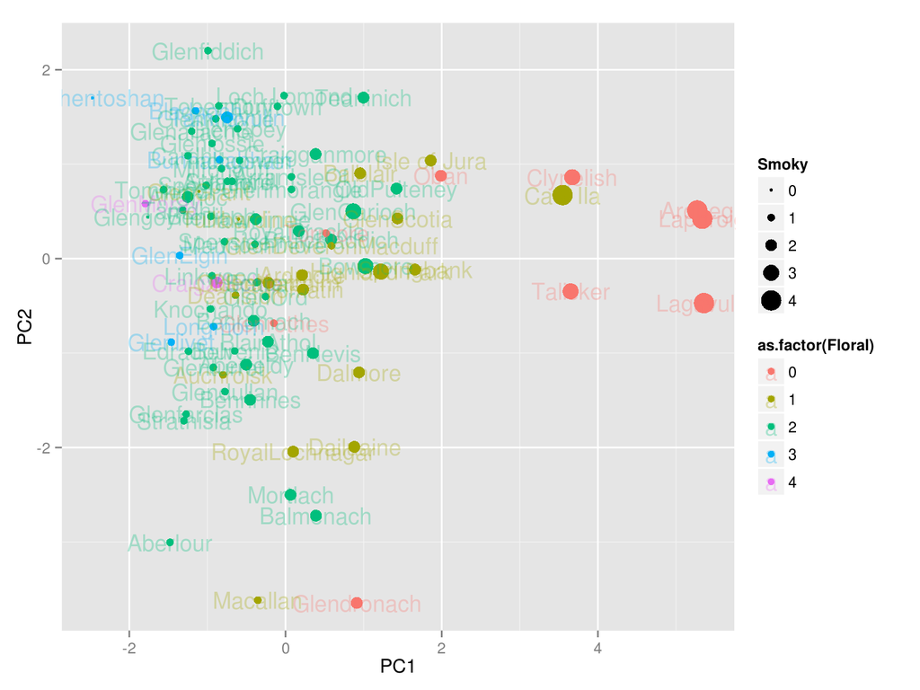

```r
df <- data.frame(whisky,pca$x)
ggplot(df, aes(x=PC1,y=PC2,label=Distillery,cex=Smoky,col=as.factor(Floral))) + geom_point() + geom_text(cex=5,alpha=0.3)
```

# Enrichment Analysis

# Theory Part I: Over-representation analysis

- “Threshold-based”: require defintion of a statistical threshold to define list of genes to test (e.g. FDR < 0.01)
- Hypergeometric test, Fisher’s Exact test is used.

The question we are asking here is;

> *“Are the number of DE genes associated with Theme X significantly greater than what we might expect by chance alone?”*

Where Theme X could be genes belonging to a particular GO (Gene Onotology) term.

# Toy example

Let’s imagine that we have a bag full of balls. Each balls represents a gene in the *gene universe*. - Paint the balls representing our selected list grey, and paint the rest red.

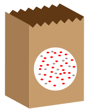

In this small example, we can define;

# Toy example

Select a number (say, 12) of the balls at random without seeing into the bag and look at what we get

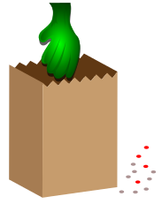

# Toy example

We have picked, at random, 8 grey balls.

- We can repeat the process and look at how many grey we get.
- We can (of course!) do this in R.
  - In base R there is a family of functions that can generate random draws from various distributions; `rnorm`, `rbinom`, `rhyper` etc….

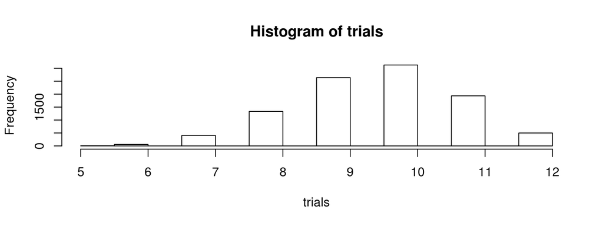

```r
#see ?rhyper for argument definition
trials <- rhyper(10000,40,10,12)
hist(trials)
```

# Toy example

```r
table(trials)
```

```
## trials
##    5    6    7    8    9   10   11   12
##    7   58  404 1333 2639 3126 1934  499
```

```r
table(trials)/10000
```

```
## trials
##      5      6      7      8      9     10     11     12
## 0.0007 0.0058 0.0404 0.1333 0.2639 0.3126 0.1934 0.0499
```

```r
cumsum(table(trials)/10000)
```

```
##      5      6      7      8      9     10     11     12
## 0.0007 0.0065 0.0469 0.1802 0.4441 0.7567 0.9501 1.0000
```

```r
1-cumsum(table(trials)/10000)
```

```
##      5      6      7      8      9     10     11     12
## 0.9993 0.9935 0.9531 0.8198 0.5559 0.2433 0.0499 0.0000
```

# Toy example

Back to our example, the distribution of balls can be expressed as a contingency table, on which we can use a Fisher’s exact test

Total grey balls: 10 Total in subset: 12

|  | Selection_in | Selection_out |
| --- | --- | --- |
| Grey_in | 8 | 2 |
| Grey_out | 4 | 26 |

# Toy example

|  | Selection_in | Selection_out | RowTotal |
| --- | --- | --- | --- |
| Grey_in | a | b | a +b |
| Grey_out | c | d | c+d |
| Column Total | a+c | b+d | a+b+c+d (=n) |

The formula for Fishers exact test is;

$p = \frac{\binom{a + b}{a}\binom{c +d}{c}}{\binom{n}{a +c}} = \frac{(a+b)!(c+d)!(a+c)!(b+d)!}{a!b!c!d!n!}$

or less formally;

*P = (ways of choosing grey balls) X (ways of non-grey balls amongst subset) / ways of choosing subset*

# Implementation in R

- We don’t need to remember this formula as R will calculate the probability for us
- We will use `goseq` in the practical
  - The package will also deal with the mapping of genes to GO cateogories
  - It has corrections for gene-length too
- Other options;
- GOstats (not specifically for NGS?)
- topGO (see [here](http://www-huber.embl.de/users/klaus/Teaching/DESeq2Predoc2014.html#gene-ontology-enrichment-analysis) for a nice worked-example)
- various others in [BioC](http://bioconductor.org/packages/release/BiocViews.html#___GeneSetEnrichment)
- online tools; DAVID, Genetrail

# Theory Part II: Threshold-free

For these tests, we don’t have to specify a statistical threshold and use the test statistics from *all* genes as the input to the test. The popular *Gene Set Enrichment Analysis (GSEA)* uses this approach. These tests can be used to detect differential expression for a group of genes, even when the effects are too small or there is too little data to detect the genes individually.

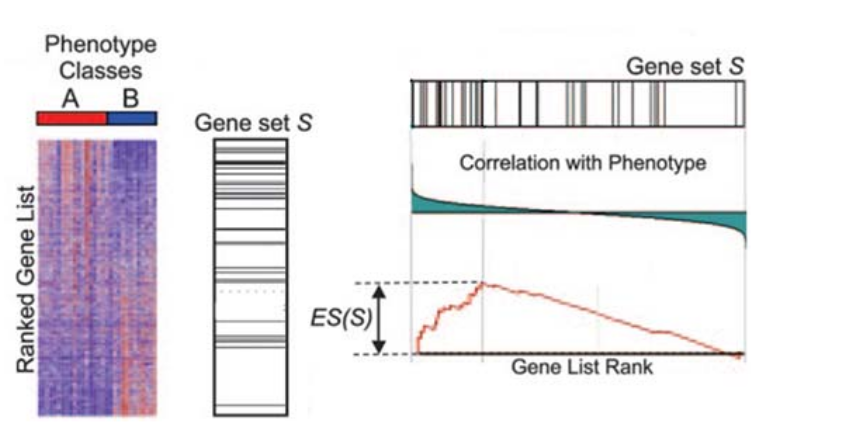

*Subramanian et al, PNAS 2005*

# Theory Part II: Threshold-free

- The Broad institute provides [a version of GSEA](http://software.broadinstitute.org/gsea/index.jsp) that can be run via a java application.
- However, it requires you to convert your data into a particular format. A more convenient option is [*GeneTrail*](http://genetrail.bioinf.uni-sb.de/enrichment_analysis.php?js=1&cc=1) which has the option to do a GSEA-style analysis.

The required input text contains a set of gene identifiers that are ordered according to some test statistic. To produce such a file, we first have to order the statistics from our test (e.g. with the `order` function)

```r
load("Day3/edgeRAnalysis_ALLGENES.RData")
y <- y[order(y$LR,decreasing = TRUE),]
write.table(y, file="genetrail-gsea.txt",sep="\t",row.names = FALSE,quote=FALSE)
```

# A Threshold-free test in Bioconductor

- Simple version of this test is implemented in the `geneSetTest` function in `limma`,
- Computes a p-value to test the hypothesis that the selected genes have more extreme test-statistics than one might expect by chance.

e.g. pick 50 genes at random.

```r
library(limma)
load("Day3/edgeRAnalysis_ALLGENES.RData")
stats <- y$logFC
myGenes <- sample(1:nrow(y),50)
geneSetTest(index = myGenes, statistics = stats)
```

```
## [1] 0.7891464
```

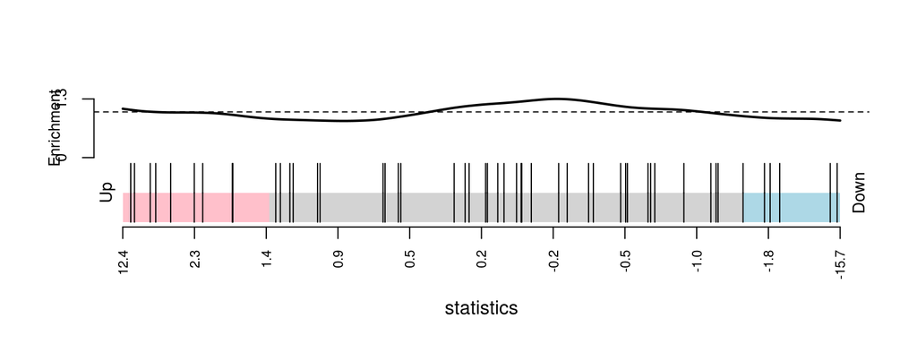

```r
barcodeplot(stats, index=myGenes)
```

# A Threshold-free test in Bioconductor

On the other hand, we could deliberately pick genes with a significant p-value and notice how the results are altered.

```r
myGenes <- which(y$FDR < 0.01)[1:50]

geneSetTest (index = myGenes , statistics = stats)
```

```
## [1] 1.30939e-33
```

```r
geneSetTest (index = myGenes , statistics = stats ,
  alternative = "down" )
```

```
## [1] 0.069947
```

```r
geneSetTest (index = myGenes , statistics = stats ,
  alternative = "up" )
```

```
## [1] 0.9300574
```

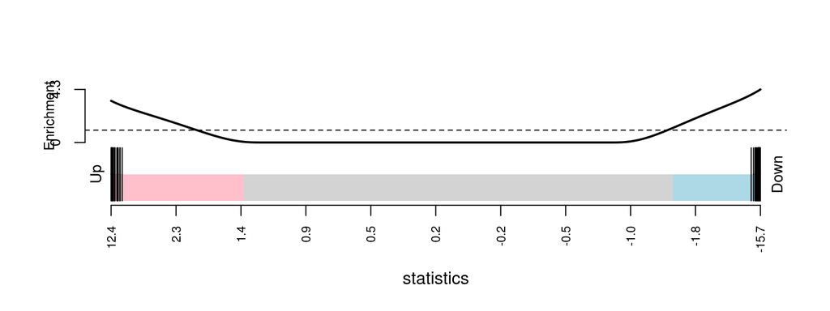

```r
barcodeplot (statistics = stats , index = myGenes )
```